# Goodreads Books Prediction - Python Machine Learning Assignment

Train a model that predicts book's rating using machine learning models.

## Data Information

1. **bookID**: A unique identification number for each book.
2. **title**: The name under which the book was published.
3. **authors**: The names of the authors of the book. Multiple authors are delimited by “/”.
4. **average_rating**: The average rating of the book received in total.
5. **isbn**: Another unique number to identify the book, known as the International Standard Book Number.
6. **isbn13**: A 13-digit ISBN to identify the book, instead of the standard 11-digit ISBN.
7. **language_code**: Indicates the primary language of the book. For instance, “eng” is standard for English.
8. **num_pages**: The number of pages the book contains.
9. **ratings_count**: The total number of ratings the book received.
10. **text_reviews_count**: The total number of written text reviews the book received.
11. **publication_date**: The date the book was published.
12. **publisher**: The name of the book publisher.

## Structure

1. Data Extraction and Processing
2. Data Cleaning
3. Exploratory Data Analysis
4. Feature Engineering.
5. Multiple Machine Learning Models.
6. Compare ML models

## Importing the Libraries

```python
import pandas as pd
import numpy as np
import matplotlib.pyplot as plt
import seaborn as sns

from sklearn.model_selection import train_test_split
from sklearn.metrics import r2_score, mean_squared_error, mean_absolute_error
from sklearn.model_selection import learning_curve, cross_val_score
from sklearn.model_selection import train_test_split
from sklearn import utils
from sklearn.linear_model import LinearRegression
from sklearn.preprocessing import OrdinalEncoder
from sklearn.preprocessing import MinMaxScaler, StandardScaler
from sklearn.metrics import r2_score, mean_squared_error
from sklearn.linear_model import LogisticRegression
from sklearn.metrics import confusion_matrix
from sklearn.metrics import plot_confusion_matrix
from sklearn import tree
from sklearn import preprocessing
from sklearn.ensemble import RandomForestRegressor
from sklearn.model_selection import GridSearchCV
from sklearn.ensemble import AdaBoostRegressor
from sklearn.tree import DecisionTreeRegressor
```

## 1. Data Extraction and Processing

```python
# loading the dataset

data = pd.read_csv('books_corrected.csv', error_bad_lines=False)
```

```python
# snapshot of the beginning of the dataset

data.head()
```

|  | bookID | title | authors | average_rating | isbn | isbn13 | language_code | num_pages | ratings_count | text_reviews_count | publication_date | publisher |
| --- | --- | --- | --- | --- | --- | --- | --- | --- | --- | --- | --- | --- |
| 0 | 1 | Harry Potter and the Half-Blood Prince (Harry ... | J.K. Rowling/Mary GrandPré | 4.57 | 439785960 | 9.780000e+12 | eng | 652 | 2095690 | 27591 | 9/16/2006 | Scholastic Inc. |
| 1 | 2 | Harry Potter and the Order of the Phoenix (Har... | J.K. Rowling/Mary GrandPré | 4.49 | 439358078 | 9.780000e+12 | eng | 870 | 2153167 | 29221 | 9/1/2004 | Scholastic Inc. |
| 2 | 4 | Harry Potter and the Chamber of Secrets (Harry... | J.K. Rowling | 4.42 | 439554896 | 9.780000e+12 | eng | 352 | 6333 | 244 | 11/1/2003 | Scholastic |
| 3 | 5 | Harry Potter and the Prisoner of Azkaban (Harr... | J.K. Rowling/Mary GrandPré | 4.56 | 043965548X | 9.780000e+12 | eng | 435 | 2339585 | 36325 | 5/1/2004 | Scholastic Inc. |
| 4 | 8 | Harry Potter Boxed Set Books 1-5 (Harry Potte... | J.K. Rowling/Mary GrandPré | 4.78 | 439682584 | 9.780000e+12 | eng | 2690 | 41428 | 164 | 9/13/2004 | Scholastic |

```python
data.tail()
```

|  | bookID | title | authors | average_rating | isbn | isbn13 | language_code | num_pages | ratings_count | text_reviews_count | publication_date | publisher |
| --- | --- | --- | --- | --- | --- | --- | --- | --- | --- | --- | --- | --- |
| 11122 | 45631 | Expelled from Eden: A William T. Vollmann Reader | William T. Vollmann/Larry McCaffery/Michael He... | 4.06 | 1560254416 | 9.780000e+12 | eng | 512 | 156 | 20 | 12/21/2004 | Da Capo Press |
| 11123 | 45633 | You Bright and Risen Angels | William T. Vollmann | 4.08 | 140110879 | 9.780000e+12 | eng | 635 | 783 | 56 | 12/1/1988 | Penguin Books |
| 11124 | 45634 | The Ice-Shirt (Seven Dreams #1) | William T. Vollmann | 3.96 | 140131965 | 9.780000e+12 | eng | 415 | 820 | 95 | 8/1/1993 | Penguin Books |
| 11125 | 45639 | Poor People | William T. Vollmann | 3.72 | 60878827 | 9.780000e+12 | eng | 434 | 769 | 139 | 2/27/2007 | Ecco |
| 11126 | 45641 | Las aventuras de Tom Sawyer | Mark Twain | 3.91 | 8497646983 | 9.790000e+12 | spa | 272 | 113 | 12 | 5/28/2006 | Edimat Libros |

```python
# dataset rows and columns

data.shape
```

```
(11127, 12)
```

```python
# data description for the column float and integer
# count, unique, min, max

data.describe()
```

|  | bookID | average_rating | isbn13 | num_pages | ratings_count | text_reviews_count |
| --- | --- | --- | --- | --- | --- | --- |
| count | 11127.000000 | 11127.000000 | 1.112700e+04 | 11127.000000 | 1.112700e+04 | 11127.000000 |
| mean | 21310.938887 | 3.933631 | 9.759178e+12 | 336.376921 | 1.793641e+04 | 541.854498 |
| std | 13093.358023 | 0.352445 | 4.428650e+11 | 241.127305 | 1.124794e+05 | 2576.176608 |
| min | 1.000000 | 0.000000 | 8.987060e+09 | 0.000000 | 0.000000e+00 | 0.000000 |
| 25% | 10287.000000 | 3.770000 | 9.780000e+12 | 192.000000 | 1.040000e+02 | 9.000000 |
| 50% | 20287.000000 | 3.960000 | 9.780000e+12 | 299.000000 | 7.450000e+02 | 46.000000 |
| 75% | 32104.500000 | 4.135000 | 9.780000e+12 | 416.000000 | 4.993500e+03 | 237.500000 |
| max | 45641.000000 | 5.000000 | 9.790000e+12 | 6576.000000 | 4.597666e+06 | 94265.000000 |

```python
data.average_rating.value_counts()
```

```
4.00    219
3.96    195
4.02    178
3.94    176
4.07    172
       ...
2.55      1
2.77      1
3.10      1
2.93      1
4.82      1
Name: average_rating, Length: 209, dtype: int64
```

```python
data.average_rating.value_counts().values
```

```
array([219, 195, 178, 176, 172, 168, 168, 168, 166, 166, 164, 163, 163,
       162, 158, 158, 156, 155, 155, 155, 154, 152, 151, 146, 146, 145,
       143, 142, 142, 140, 138, 138, 137, 136, 134, 133, 129, 124, 122,
       122, 115, 114, 113, 112, 111, 109, 109, 109, 108, 102, 101, 100,
        96,  96,  94,  94,  92,  90,  90,  84,  83,  82,  76,  74,  73,
        72,  70,  68,  67,  62,  62,  61,  60,  60,  58,  58,  58,  52,
        52,  49,  48,  46,  46,  46,  43,  41,  41,  40,  39,  39,  39,
        37,  37,  37,  36,  36,  36,  34,  32,  30,  30,  30,  28,  27,
        26,  26,  25,  25,  22,  22,  22,  21,  19,  19,  18,  17,  16,
        16,  15,  15,  15,  15,  14,  14,  13,  13,  13,  13,  12,  12,
        11,  11,  10,   9,   8,   8,   8,   8,   8,   8,   8,   8,   7,
         7,   7,   7,   7,   6,   6,   6,   6,   5,   5,   5,   5,   5,
         5,   5,   4,   4,   4,   4,   4,   4,   4,   4,   3,   3,   3,
         3,   3,   2,   2,   2,   2,   2,   2,   2,   2,   2,   2,   2,
         2,   1,   1,   1,   1,   1,   1,   1,   1,   1,   1,   1,   1,
         1,   1,   1,   1,   1,   1,   1,   1,   1,   1,   1,   1,   1,
         1], dtype=int64)
```

```python
data.average_rating.value_counts().index
```

```
Float64Index([ 4.0, 3.96, 4.02, 3.94, 4.07, 3.93, 3.92, 4.05, 3.83, 3.89,
              ...
              4.91, 2.81, 1.67, 2.61, 2.33, 2.55, 2.77,  3.1, 2.93, 4.82],
             dtype='float64', length=209)
```

```
<BarContainer object of 209 artists>
```

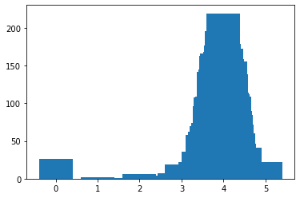

```python
plt.bar(data.average_rating.value_counts().index,data.average_rating.value_counts().values)
```

```python
# data information

data.info()
```

```
<class 'pandas.core.frame.DataFrame'>
RangeIndex: 11127 entries, 0 to 11126
Data columns (total 12 columns):
 #   Column              Non-Null Count  Dtype
---  ------              --------------  -----
 0   bookID              11127 non-null  int64
 1   title               11127 non-null  object
 2   authors             11127 non-null  object
 3   average_rating      11127 non-null  float64
 4   isbn                11127 non-null  object
 5   isbn13              11127 non-null  float64
 6   language_code       11127 non-null  object
 7     num_pages         11127 non-null  int64
 8   ratings_count       11127 non-null  int64
 9   text_reviews_count  11127 non-null  int64
 10  publication_date    11127 non-null  object
 11  publisher           11127 non-null  object
dtypes: float64(2), int64(4), object(6)
memory usage: 1.0+ MB
```

## Data Cleaning

```python
#Fixing the name for every author

#example for Harry Potter series : df.replace(to_replace='J.K. Rowling/Mary GrandPré', value = 'J.K. Rowling', inplace=True) or

data['authors'] = data['authors'].apply(lambda x: x.split("/")[0])
```

```python
#Displaying the name change

data.head()
```

|  | bookID | title | authors | average_rating | isbn | isbn13 | language_code | num_pages | ratings_count | text_reviews_count | publication_date | publisher |
| --- | --- | --- | --- | --- | --- | --- | --- | --- | --- | --- | --- | --- |
| 0 | 1 | Harry Potter and the Half-Blood Prince (Harry ... | J.K. Rowling | 4.57 | 439785960 | 9.780000e+12 | eng | 652 | 2095690 | 27591 | 9/16/2006 | Scholastic Inc. |
| 1 | 2 | Harry Potter and the Order of the Phoenix (Har... | J.K. Rowling | 4.49 | 439358078 | 9.780000e+12 | eng | 870 | 2153167 | 29221 | 9/1/2004 | Scholastic Inc. |
| 2 | 4 | Harry Potter and the Chamber of Secrets (Harry... | J.K. Rowling | 4.42 | 439554896 | 9.780000e+12 | eng | 352 | 6333 | 244 | 11/1/2003 | Scholastic |
| 3 | 5 | Harry Potter and the Prisoner of Azkaban (Harr... | J.K. Rowling | 4.56 | 043965548X | 9.780000e+12 | eng | 435 | 2339585 | 36325 | 5/1/2004 | Scholastic Inc. |
| 4 | 8 | Harry Potter Boxed Set Books 1-5 (Harry Potte... | J.K. Rowling | 4.78 | 439682584 | 9.780000e+12 | eng | 2690 | 41428 | 164 | 9/13/2004 | Scholastic |

```python
# Finding null values

data.isnull().sum()
```

```
bookID                0
title                 0
authors               0
average_rating        0
isbn                  0
isbn13                0
language_code         0
  num_pages           0
ratings_count         0
text_reviews_count    0
publication_date      0
publisher             0
dtype: int64
```

```python
# Finding the duplicates

data.duplicated().sum()
```

```
0
```

```python
# Checking for duplicates

data.duplicated().any()
```

```
False
```

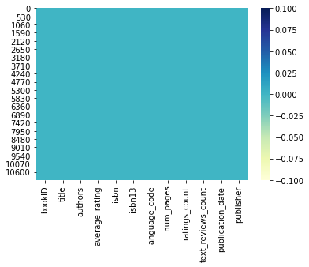

```python
# Visualizing the above result with a heatmap

sns.heatmap(data.isnull(), cmap='YlGnBu')
```

```python
#Identifying the type of categories

def identify_number_categories(data):
    """
    This definition can be used to identify the number of categories of every categorical feature

    @param df DataFrame

    @return a DataFrame with the categorical features and number of categories"""

    categorical_columns = list(data.select_dtypes(['object']).columns)

    cat_data = []

    for c in categorical_columns:
        cat_data.append({"categorical_feature": c,
                       "number_categories": len(data[c].value_counts(dropna = False))
                    })

    return pd.DataFrame(cat_data).sort_values(by = "number_categories", ascending = False)

identify_number_categories(data)
```

|  | categorical_feature | number_categories |
| --- | --- | --- |
| 2 | isbn | 11127 |
| 0 | title | 10352 |
| 1 | authors | 4219 |
| 4 | publication_date | 3679 |
| 5 | publisher | 2292 |
| 3 | language_code | 27 |

```python
#Re-checking for any missing data

def identify_missing_data(data):
    """
    This function is used to identify missing data

    @param df pandas DataFrame

    @return a DataFrame with the percentage of missing data for every feature and the data types
    """


    percent_missing = data.isnull().mean()

    missing_value_data = pd.DataFrame(percent_missing).reset_index() # convert to DataFrame
    missing_value_data = missing_value_data.rename(columns = {"index" : "feature",
                                                                0 : "percent_missing"}) # rename columns

    missing_value_data = missing_value_data.sort_values(by = ['percent_missing'], ascending = False) # sort the values

    data_types_data = pd.DataFrame(data.dtypes).reset_index().rename(columns = {"index" : "feature",
                                                                0 : "data_type"}) # rename columns

    missing_value_data = missing_value_data.merge(data_types_data, on = "feature") # join the dataframe with datatype

    missing_value_data.percent_missing = round(missing_value_data.percent_missing*100, 2) # format the percent_missing

    return missing_value_data
```

```python
missing_value_data = identify_missing_data(data)
missing_value_data[missing_value_data.percent_missing>0]
```

|  | feature | percent_missing | data_type |
| --- | --- | --- | --- |

```python
# Converting data type of publication_date from object into date type

data['publication_date'] = pd.to_datetime(data['publication_date'], format='%m/%d/%Y', errors='coerce')
data[data['publication_date'].isnull()]
```

|  | bookID | title | authors | average_rating | isbn | isbn13 | language_code | num_pages | ratings_count | text_reviews_count | publication_date | publisher |
| --- | --- | --- | --- | --- | --- | --- | --- | --- | --- | --- | --- | --- |
| 8180 | 31373 | In Pursuit of the Proper Sinner (Inspector Lyn... | Elizabeth George | 4.10 | 553575104 | 9.780000e+12 | eng | 718 | 10608 | 295 | NaT | Bantam Books |
| 11098 | 45531 | Montaillou village occitan de 1294 à 1324 | Emmanuel Le Roy Ladurie | 3.96 | 2070323285 | 9.780000e+12 | fre | 640 | 15 | 2 | NaT | Folio histoire |

*There were 2 books with courrpted dates, so the publication dates of these 2 books were retrieved from a google search and inserted manually*

```python
# Inserting publication date of two books with corrupted dates manually

data.loc[data.bookID == 31373, 'publication_date'] = '1999-10-01 00:00:00'
data.loc[data.bookID == 45531, 'publication_date'] = '1975-10-01 00:00:00'
```

```python
# Extracting year of publication in a separate column

data['year'] = pd.DatetimeIndex(data['publication_date']).year

# Renaming the column to remove leading whitespaces

data.rename(columns = {'  num_pages': 'num_pages'}, inplace=True)
```

```python
# Adding a new feature which has the number of occurences of each book

data['num_occ'] = data.groupby('title')['title'].transform('count')
```

```python
# This method shows the correlation matrix of the columns (attributes)

data.corr()
```

|  | bookID | average_rating | isbn13 | num_pages | ratings_count | text_reviews_count | year | num_occ |
| --- | --- | --- | --- | --- | --- | --- | --- | --- |
| bookID | 1.000000 | -0.036949 | -0.002228 | -0.026223 | -0.076815 | -0.081284 | 0.027009 | -0.112636 |
| average_rating | -0.036949 | 1.000000 | -0.002075 | 0.150809 | 0.038205 | 0.033734 | -0.028804 | 0.016482 |
| isbn13 | -0.002228 | -0.002075 | 1.000000 | -0.009680 | 0.005560 | 0.008232 | -0.000485 | 0.013057 |
| num_pages | -0.026223 | 0.150809 | -0.009680 | 1.000000 | 0.034353 | 0.036998 | -0.019310 | 0.063084 |
| ratings_count | -0.076815 | 0.038205 | 0.005560 | 0.034353 | 1.000000 | 0.865979 | 0.044580 | 0.092380 |
| text_reviews_count | -0.081284 | 0.033734 | 0.008232 | 0.036998 | 0.865979 | 1.000000 | 0.066926 | 0.070026 |
| year | 0.027009 | -0.028804 | -0.000485 | -0.019310 | 0.044580 | 0.066926 | 1.000000 | -0.001627 |
| num_occ | -0.112636 | 0.016482 | 0.013057 | 0.063084 | 0.092380 | 0.070026 | -0.001627 | 1.000000 |

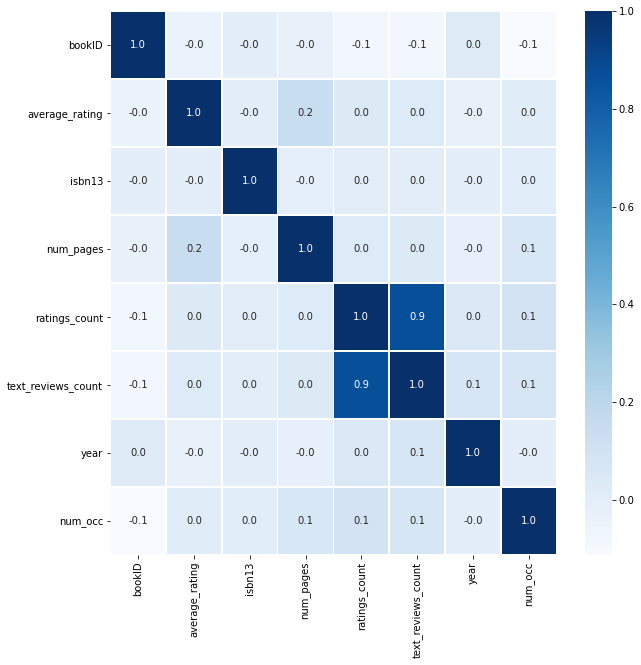

```python
# This method creates a figure and a set of subplots. Then, returns figure and axis infos.
fig, axes = plt.subplots(figsize=(10, 10))
# Figure out heatmap
sns.heatmap(data=data.corr(), cmap = "Blues", annot=True, linewidths=.5, fmt=".1f", ax=axes)
# Parameters:
# data : 2D data for the heatmap.
# annot : If True, write the data value in each cell.
# linewidths : Width of the lines that will divide each cell.
# fmt : String formatting code to use when adding annotations.
# ax : Axes in which to draw the plot, otherwise use the currently-active Axes.
plt.show() # Shows only plot and remove other info
```

*As you can see, it found only the correlation of numerical data and presented his Heatmap. For string-type data, doing this is unreasonable and distressing.*

```python
categorical_columns = list(data.select_dtypes(['object']).columns)
categorical_columns
```

```
['title', 'authors', 'isbn', 'language_code', 'publication_date', 'publisher']
```

## Exploratory Data Analysis

*In this section we analyse the data and create visualizations to understand the data better.*

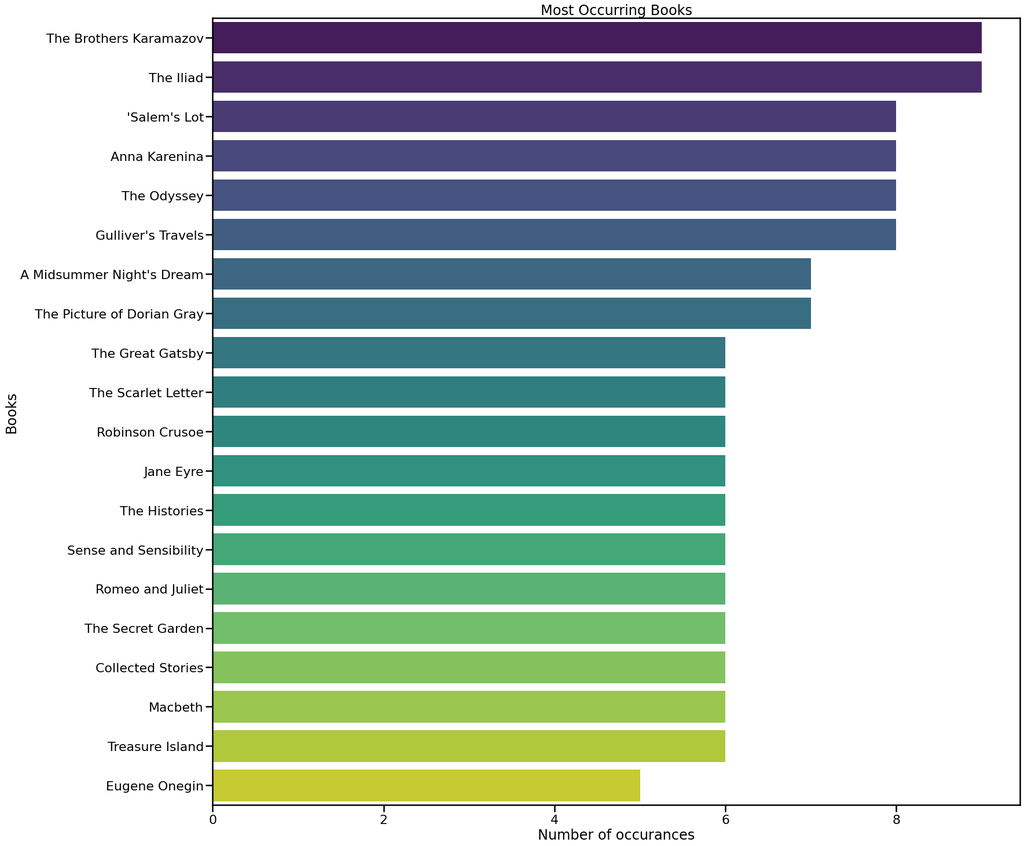

```python
#Taking the first 20:

sns.set_context('poster')
plt.figure(figsize=(25,25))
books = data['title'].value_counts()[:20]
rating = data.average_rating[:20]
sns.barplot(x = books, y = books.index, palette='viridis')
plt.title("Most Occurring Books")
plt.xlabel("Number of occurances")
plt.ylabel("Books")
plt.show()
```

*From the list, we can see that most of the books from the given chart are classics.*

[output not shown]

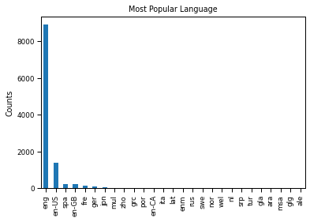

```python
#Distribution of book languages

data['language_code'].value_counts().plot(kind='bar')
plt.title('Most Popular Language')
plt.ylabel('Counts')
plt.xticks(rotation = 90)
```

*The graph above suggests that majority of the books are in english languages, with some further categorised into English-US, english-UK and english-CA in the provided dataset.*

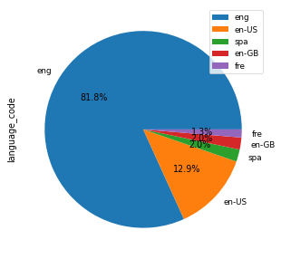

```python
# Top 5 languages

data['language_code'].value_counts().head(5).plot(kind = 'pie', autopct='%1.1f%%', figsize=(5, 5)).legend()
```

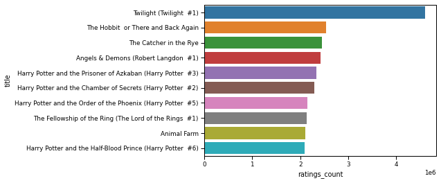

```python
# highest rated books
popular_books = data.nlargest(10, ['ratings_count']).set_index('title')['ratings_count']
sns.barplot(popular_books, popular_books.index)
```

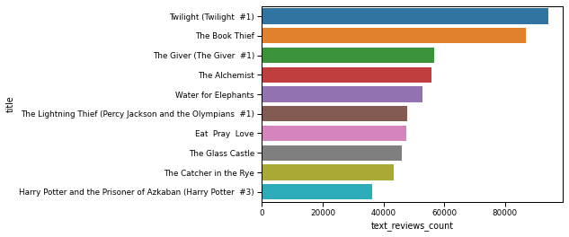

```python
# Highest reviewed books
highest_reviews = data.nlargest(10, ['text_reviews_count'])
sns.barplot(highest_reviews['text_reviews_count'], highest_reviews['title'])
```

[output not shown]

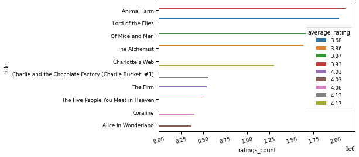

```python
# top 10 books under 200 pages
under200 = data[data['num_pages'] <= 200]
top10under200 = under200.nlargest(10, ['ratings_count'])
sns.barplot(top10under200['ratings_count'], top10under200['title'], hue=top10under200['average_rating'])
plt.xticks(rotation=15)
```

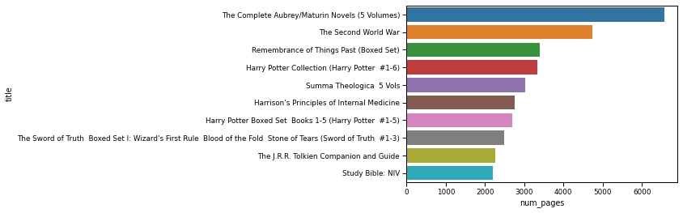

```python
# top 10 longest books
longest_books = data.nlargest(10, ['num_pages']).set_index('title')
sns.barplot(longest_books['num_pages'], longest_books.index)
```

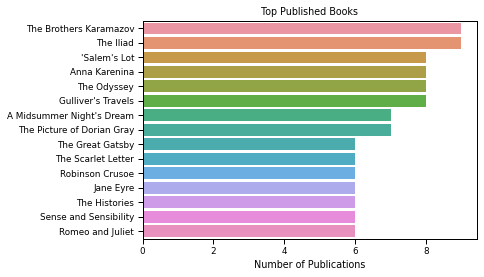

```python
# top published books
sns.barplot(data['title'].value_counts()[:15], data['title'].value_counts().index[:15])
plt.title('Top Published Books')
plt.xlabel('Number of Publications')
```

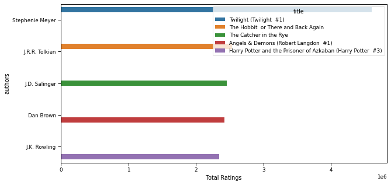

```python
# authors with highest rated books
plt.figure(figsize=(10, 5))
authors = data.nlargest(5, ['ratings_count']).set_index('authors')
sns.barplot(authors['ratings_count'], authors.index, ci = None, hue = authors['title'])
plt.xlabel('Total Ratings')
```

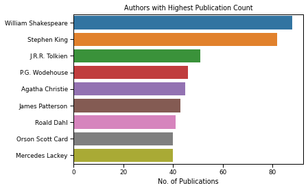

```python
# authors with highest publications
top_authors = data['authors'].value_counts().head(9)
sns.barplot(top_authors, top_authors.index)
plt.title('Authors with Highest Publication Count')
plt.xlabel('No. of Publications')
```

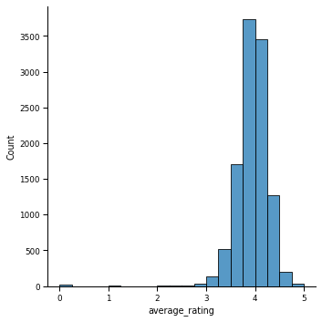

```python
#ratings distribution 1
plt.figure(figsize=(10,10))
rating= data.average_rating.astype(float)
sns.displot(rating, bins=20)
```

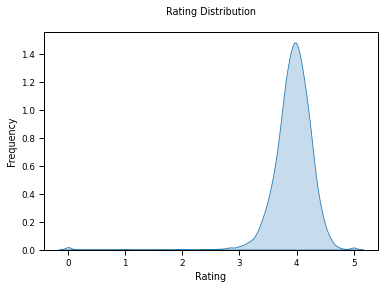

```python
# ratings distribution 2
sns.kdeplot(data['average_rating'], shade = True)
plt.title('Rating Distribution\n')
plt.xlabel('Rating')
plt.ylabel('Frequency')
```

*We can see from the above plot that books having the rating score of 5 is rare and that most of the rating scores lie between 3.7 - 4.3 approximately.*

```python
def segregation(data):
    values = []
    for val in data.average_rating:
        if val>=0 and val<=1:
            values.append("Between 0 and 1")
        elif val>1 and val<=2:
            values.append("Between 1 and 2")
        elif val>2 and val<=3:
            values.append("Between 2 and 3")
        elif val>3 and val<=4:
            values.append("Between 3 and 4")
        elif val>4 and val<=5:
            values.append("Between 4 and 5")
        else:
            values.append("NaN")
    print(len(values))
    return values
```

```python
data.average_rating.isnull().value_counts()
```

```
False    11127
Name: average_rating, dtype: int64
```

```
11127
```

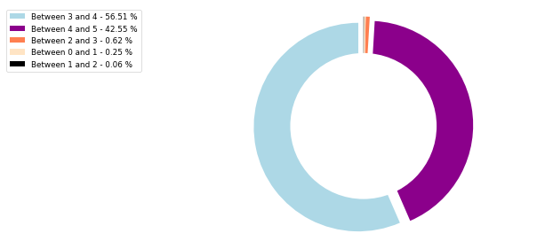

```python
data['Ratings_Dist'] = segregation(data)
ratings_pie = data['Ratings_Dist'].value_counts().reset_index()
labels = ratings_pie['index']
colors = ['lightblue','darkmagenta','coral','bisque', 'black']
percent = 100.*ratings_pie['Ratings_Dist']/ratings_pie['Ratings_Dist'].sum()
fig, ax1 = plt.subplots()
ax1.pie(ratings_pie['Ratings_Dist'],colors = colors,
        pctdistance=0.85, startangle=90, explode=(0.05, 0.05, 0.05, 0.05, 0.05))
#Draw a circle now:
centre_circle = plt.Circle((0,0), 0.70, fc ='white')
fig1 = plt.gcf()
fig1.gca().add_artist(centre_circle)
#Equal Aspect ratio ensures that pie is drawn as a circle
plt.axis('equal')
plt.tight_layout()
labels = ['{0} - {1:1.2f} %'.format(i,j) for i,j in zip(labels, percent)]
plt.legend( labels, loc = 'best',bbox_to_anchor=(-0.1, 1.),)
```

*From the above graph it can be observed that the majority of the ratings are between 3 and 4 followed closely by the other major chunk of the ratings lying between 4 and 5.*

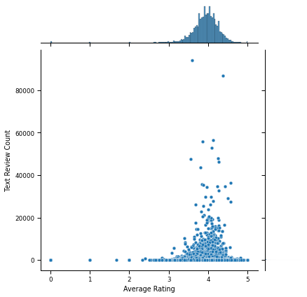

```python
# relationship between ratings and review counts

plt.figure(figsize=(15,10))
data.dropna(0, inplace=True)
sns.set_context('paper')
ax =sns.jointplot(x="average_rating",y='text_reviews_count', kind='scatter',  data= data[['text_reviews_count', 'average_rating']])
ax.set_axis_labels("Average Rating", "Text Review Count")
plt.show()
```

*We can infer from the plot that most of the ratings for the books seems to lie near 3-4, with a heavy amount of reviews lying barely near 5000, approximately.*

```python
trial = data[~(data['text_reviews_count']>5000)]
```

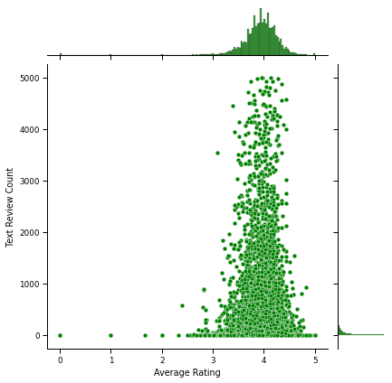

```python
#Checking for any relation between them.
plt.figure(figsize=(15,10))
data.dropna(0, inplace=True)
sns.set_context('paper')
ax =sns.jointplot(x="average_rating",y='text_reviews_count', kind='scatter',  data= trial, color = 'green')
ax.set_axis_labels("Average Rating", "Text Review Count")
plt.show()
```

*It can be observed that even now, the majority of text reviews for books still lie under 1000, thus we can't infer much from it.*

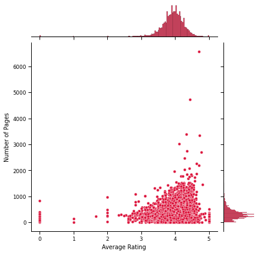

```python
#relationship between number of pages and ratings

plt.figure(figsize=(15,10))
sns.set_context('paper')
ax = sns.jointplot(x="average_rating", y="num_pages", data = data, color = 'crimson')
ax.set_axis_labels("Average Rating", "Number of Pages")
```

*This plot doesn't give that much of an accurate inference due to the massive presence of outliers for books above 1000 pages, for the maximum density is between 0-1000 pages.*

```python
trial = data[~(data['num_pages']>1000)]
```

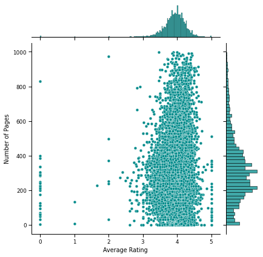

```python
ax = sns.jointplot(x="average_rating", y="num_pages", data = trial, color = 'darkcyan')
ax.set_axis_labels("Average Rating", "Number of Pages")
```

*From the above plot, we can infer that the highest ratings ever given, usually are for books with the page range of 200-400, peaking near 250.*

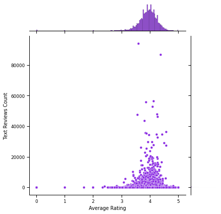

```python
#relationship between text reviews and ratings
sns.set_context('paper')
ax = sns.jointplot(x="average_rating", y="text_reviews_count", data = data, color = 'blueviolet')
ax.set_axis_labels("Average Rating", "Text Reviews Count")
```

## Feature Engineering

*Feature Engineering is the conversion of data into machine-readable form can be interpreted, analysed and used by machine learning algorithms.*

```python
encoding = {'language_code':{'en-US': 'eng', 'en-GB': 'eng', 'en-CA': 'eng'}} # Unify the langauge codes
data.replace(encoding, inplace=True)

enc = OrdinalEncoder()
enc.fit(data[['language_code']])
data[['language_code']] = enc.fit_transform(data[['language_code']]) # Apply ordinal encoding on language_code to convert it into numerical column
```

```python
data.head()
```

|  | bookID | title | authors | average_rating | isbn | isbn13 | language_code | num_pages | ratings_count | text_reviews_count | publication_date | publisher | year | num_occ | Ratings_Dist |
| --- | --- | --- | --- | --- | --- | --- | --- | --- | --- | --- | --- | --- | --- | --- | --- |
| 0 | 1 | Harry Potter and the Half-Blood Prince (Harry ... | J.K. Rowling | 4.57 | 439785960 | 9.780000e+12 | 2.0 | 652 | 2095690 | 27591 | 2006-09-16 00:00:00 | Scholastic Inc. | 2006 | 2 | Between 4 and 5 |
| 1 | 2 | Harry Potter and the Order of the Phoenix (Har... | J.K. Rowling | 4.49 | 439358078 | 9.780000e+12 | 2.0 | 870 | 2153167 | 29221 | 2004-09-01 00:00:00 | Scholastic Inc. | 2004 | 1 | Between 4 and 5 |
| 2 | 4 | Harry Potter and the Chamber of Secrets (Harry... | J.K. Rowling | 4.42 | 439554896 | 9.780000e+12 | 2.0 | 352 | 6333 | 244 | 2003-11-01 00:00:00 | Scholastic | 2003 | 2 | Between 4 and 5 |
| 3 | 5 | Harry Potter and the Prisoner of Azkaban (Harr... | J.K. Rowling | 4.56 | 043965548X | 9.780000e+12 | 2.0 | 435 | 2339585 | 36325 | 2004-05-01 00:00:00 | Scholastic Inc. | 2004 | 2 | Between 4 and 5 |
| 4 | 8 | Harry Potter Boxed Set Books 1-5 (Harry Potte... | J.K. Rowling | 4.78 | 439682584 | 9.780000e+12 | 2.0 | 2690 | 41428 | 164 | 2004-09-13 00:00:00 | Scholastic | 2004 | 1 | Between 4 and 5 |

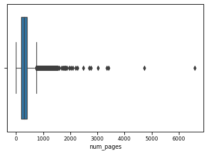

```python
# find no. of pages outliers
sns.boxplot(x=data['num_pages'])
```

*Above plot shows points between 1,000 to 6,000, these are outliers as there are not included in the box of other observation i.e no where near the quartiles.*

```python
# remove outliers from no. of pages
data = data.drop(data.index[data['num_pages'] >= 1000])
```

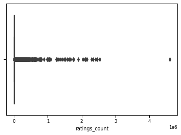

```python
# find ratings count outliers
sns.boxplot(x=data['ratings_count'])
```

*Above plot shows points between 1,000,000 to 5,000,000 are outliers.*

```python
# remove outliers from ratings_count
data = data.drop(data.index[data['ratings_count'] >= 1000000])
```

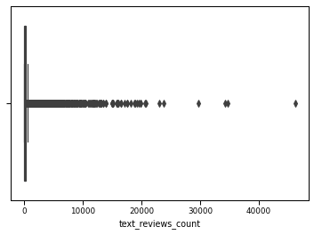

```python
# find text reviews count outliers
sns.boxplot(x=data['text_reviews_count'])
```

```python
# remove outliers from text_reviews_count
data = data.drop(data.index[data['text_reviews_count'] >= 20000])
```

```python
data.head()
```

|  | bookID | title | authors | average_rating | isbn | isbn13 | language_code | num_pages | ratings_count | text_reviews_count | publication_date | publisher | year | num_occ | Ratings_Dist |
| --- | --- | --- | --- | --- | --- | --- | --- | --- | --- | --- | --- | --- | --- | --- | --- |
| 2 | 4 | Harry Potter and the Chamber of Secrets (Harry... | J.K. Rowling | 4.42 | 439554896 | 9.780000e+12 | 2.0 | 352 | 6333 | 244 | 2003-11-01 00:00:00 | Scholastic | 2003 | 2 | Between 4 and 5 |
| 5 | 9 | Unauthorized Harry Potter Book Seven News: "Ha... | W. Frederick Zimmerman | 3.74 | 976540606 | 9.780000e+12 | 2.0 | 152 | 19 | 1 | 2005-04-26 00:00:00 | Nimble Books | 2005 | 1 | Between 3 and 4 |
| 7 | 12 | The Ultimate Hitchhiker's Guide: Five Complete... | Douglas Adams | 4.38 | 517226952 | 9.780000e+12 | 2.0 | 815 | 3628 | 254 | 2005-11-01 00:00:00 | Gramercy Books | 2005 | 1 | Between 4 and 5 |
| 8 | 13 | The Ultimate Hitchhiker's Guide to the Galaxy ... | Douglas Adams | 4.38 | 345453743 | 9.780000e+12 | 2.0 | 815 | 249558 | 4080 | 2002-04-30 00:00:00 | Del Rey Books | 2002 | 1 | Between 4 and 5 |
| 9 | 14 | The Hitchhiker's Guide to the Galaxy (Hitchhik... | Douglas Adams | 4.22 | 1400052920 | 9.780000e+12 | 2.0 | 215 | 4930 | 460 | 2004-08-03 00:00:00 | Crown | 2004 | 4 | Between 4 and 5 |

*Many machine learning algorithms require that their input is numerical and therefore categorical features such as title, authors and language code must be transformed into numerical features before we can use any of these algorithms.*

```python
data = data.drop(columns = ['isbn13', 'publication_date', 'publisher', 'year', 'num_occ', 'Ratings_Dist'])
```

```python
data.head()
```

|  | bookID | title | authors | average_rating | isbn | language_code | num_pages | ratings_count | text_reviews_count |
| --- | --- | --- | --- | --- | --- | --- | --- | --- | --- |
| 2 | 4 | Harry Potter and the Chamber of Secrets (Harry... | J.K. Rowling | 4.42 | 439554896 | 2.0 | 352 | 6333 | 244 |
| 5 | 9 | Unauthorized Harry Potter Book Seven News: "Ha... | W. Frederick Zimmerman | 3.74 | 976540606 | 2.0 | 152 | 19 | 1 |
| 7 | 12 | The Ultimate Hitchhiker's Guide: Five Complete... | Douglas Adams | 4.38 | 517226952 | 2.0 | 815 | 3628 | 254 |
| 8 | 13 | The Ultimate Hitchhiker's Guide to the Galaxy ... | Douglas Adams | 4.38 | 345453743 | 2.0 | 815 | 249558 | 4080 |
| 9 | 14 | The Hitchhiker's Guide to the Galaxy (Hitchhik... | Douglas Adams | 4.22 | 1400052920 | 2.0 | 215 | 4930 | 460 |

```python
# encode title column
le = preprocessing.LabelEncoder()
data['title'] = le.fit_transform(data['title'])
```

```python
# encode authors column
data['authors'] = le.fit_transform(data['authors'])
```

```python
data.head()
```

|  | bookID | title | authors | average_rating | isbn | language_code | num_pages | ratings_count | text_reviews_count |
| --- | --- | --- | --- | --- | --- | --- | --- | --- | --- |
| 2 | 4 | 3014 | 1592 | 4.42 | 439554896 | 2.0 | 352 | 6333 | 244 |
| 5 | 9 | 9507 | 4034 | 3.74 | 976540606 | 2.0 | 152 | 19 | 1 |
| 7 | 12 | 8948 | 981 | 4.38 | 517226952 | 2.0 | 815 | 3628 | 254 |
| 8 | 13 | 8947 | 981 | 4.38 | 345453743 | 2.0 | 815 | 249558 | 4080 |
| 9 | 14 | 7662 | 981 | 4.22 | 1400052920 | 2.0 | 215 | 4930 | 460 |